# MA554 Applied Multivariate Analysis HW1

Aukkawut Ammartayakun

2023-09-19

## Problem 1

Paper is manufactured in continuous sheets several feet wide. Because of the orientation of fibers within the paper, it has a different strength when measured in the direction produced by the machine than when measured across, or at right angles to, the machine direction. The dataset in `T1-2.txt` contains 41 measurements of $X_1$ = density (grams/cubic centimeter), $X_2$ = strength (pounds) in the machine direction, and $X_3$ = strength (pounds) in the cross direction. Use any statistical package to answer the following.

#### a) Report summary statistics (means and variances) of the three variables, and present a scatter plot matrix.

```r
var_summary <- function(data) {
    s <- summary(data)
    var_data <- sapply(data, var, na.rm = TRUE)
    r <- rbind(s, Variance = var_data)
    return(r)
}
var_summary(data)
```

```
##                              Density             Strength MD
##          "Mode:logical  " "Min.   :0.7580  "    "Min.   :103.5  "
##          "NA's:41       " "1st Qu.:0.7950  "    "1st Qu.:115.1  "
##          NA               "Median :0.8150  "    "Median :121.4  "
##          NA               "Mean   :0.8119  "    "Mean   :121.0  "
##          NA               "3rd Qu.:0.8260  "    "3rd Qu.:126.7  "
##          NA               "Max.   :0.9710  "    "Max.   :135.1  "
## Variance NA               "0.00126457804878049" "59.3211480487805"
##           Strength CD
##          "Min.   :48.93  "
##          "1st Qu.:56.53  "
##          "Median :70.70  "
##          "Mean   :67.72  "
##          "3rd Qu.:74.89  "
##          "Max.   :80.33  "
## Variance "95.8566671951219"
```

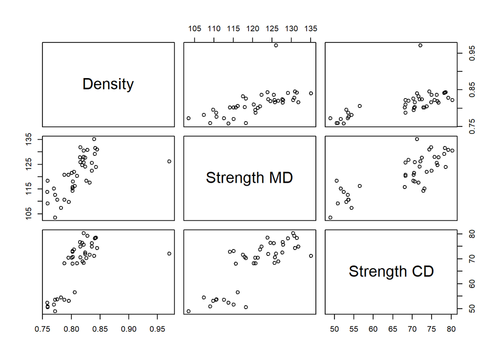

#### b) Identify an outlier

Visually, we can see that the point where density is greater than $0.96$. That is the maximum of the density.

```r
outlier <- data[data$Density == max(data$Density), ]
outlier
```

```
## # A tibble: 1 × 4
##   ``    Density `Strength MD` `Strength CD`
##   <lgl>   <dbl>         <dbl>         <dbl>
## 1 NA      0.971          126.          72.1
```

## Problem 2

Consider a bivariate normal distribution for $\mathbf{X} = (X_1,X_2)^\top$, with $\mathbb{E}\left[X_1\right] = 3, \mathbb{E}\left[X_2\right] = 5, \text{Var}\left[X_{1}\right] = 10, \text{Var}\left[X_2\right] = 4, \text{Corr}\left(X_1,X_2\right) = 0.9$

#### a) Sketch a contour of the density

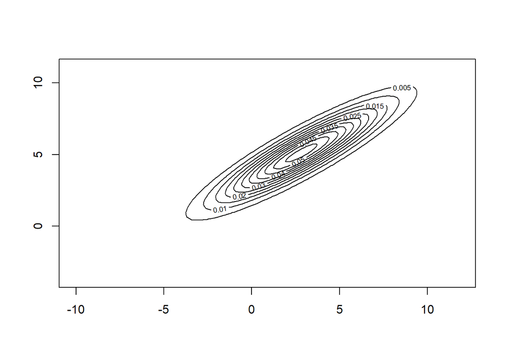

```r
library(mvtnorm)
library(MASS)
mu <- c(3, 5)
sigma1 <- sqrt(10)
sigma2 <- sqrt(4)
rho <- 0.9
cov_12 <- rho * sigma1 * sigma2
Sigma <- matrix(c(10, cov_12, cov_12, 4), ncol=2)
samples <- mvrnorm(n = 100, mu = mu, Sigma = Sigma)
x <- seq(min(samples[,1]) - 1, max(samples[,1]) + 1, length=100)
y <- seq(min(samples[,2]) - 1, max(samples[,2]) + 1, length=100)
z <- matrix(0, ncol=length(x), nrow=length(y))
for (i in 1:length(x)) {
  for (j in 1:length(y)) {
    z[j,i] <- dmvnorm(c(x[i], y[j]), mean=mu, sigma=Sigma)
  }
}

contour(x, y, z)
```

#### b) Generate $n = 100$ random observations from this distribution, and draw a scatterplot of the observation.

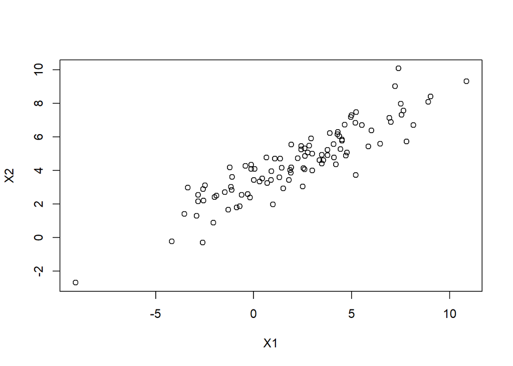

```r
plot(samples, xlab="X1", ylab="X2")
```

#### c) Report the sample mean, and compare it with the population mean.

```r
summary(samples)
```

```
##        V1                V2
##  Min.   :-9.0841   Min.   :-2.681
##  1st Qu.:-0.2083   1st Qu.: 3.101
##  Median : 2.4666   Median : 4.511
##  Mean   : 2.2410   Mean   : 4.509
##  3rd Qu.: 4.5121   3rd Qu.: 5.736
##  Max.   :10.8645   Max.   :10.077
```

#### d) Report the sample covariance matrix $S$, and sketch the equidistance set given by the sample Mahalanobis distance, i.e., $E_c= \{\mathbf{y} \in \mathbb{R}^2 | (\mathbf{y} - \bar{\mathbf{x}})^\top S^{-1} (\mathbf{y} - \bar{\mathbf{x}}) = c^2\}$ for $c>0$

```r
sample_mean <- colMeans(samples)
sample_cov <- cov(samples)
sample_cov
```

```
##           [,1]     [,2]
## [1,] 12.129633 6.683623
## [2,]  6.683623 4.502252
```

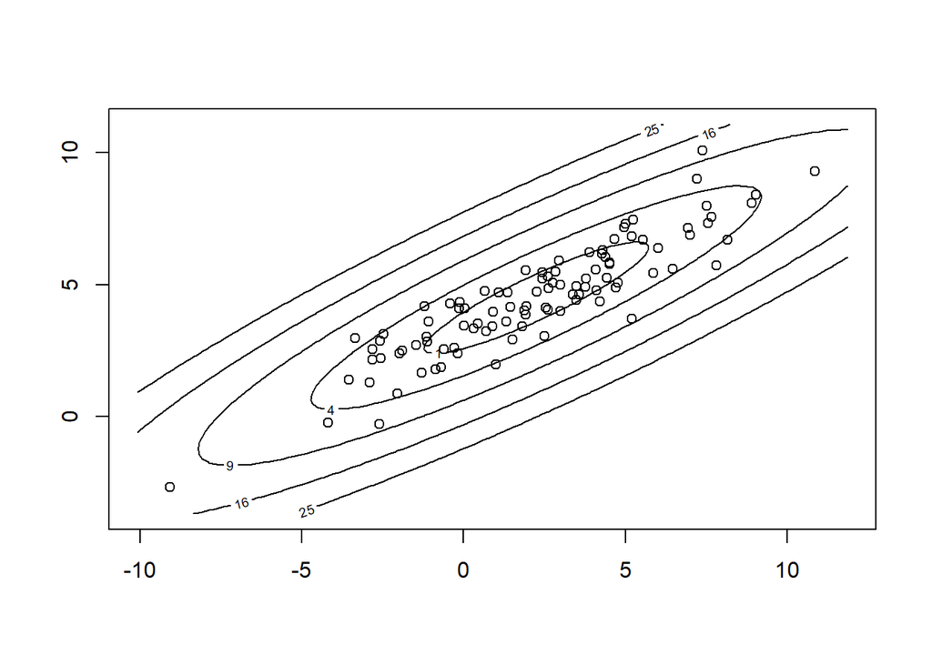

```r
c_values <- c(1,2,3,4,5)
x_range <- seq(min(samples[,1]) - 1, max(samples[,1]) + 1, length=100)
y_range <- seq(min(samples[,2]) - 1, max(samples[,2]) + 1, length=100)
grid <- expand.grid(x=x_range, y=y_range)
mahalanobis_grid <- apply(grid, 1, function(point) {
  mahalanobis(matrix(point, ncol=2), center=sample_mean, cov=sample_cov)
})
mahalanobis_matrix <- matrix(mahalanobis_grid, ncol=length(x_range))
contour(x_range, y_range, mahalanobis_matrix, levels=c_values^2)
points(samples)
```

## Problem 3

By expressing a correlation matrix $\mathbf{R}_{n\times n}$ with equal correlation $\rho$ as $\mathbf{R} = (1-\rho)\mathbb{I} + \rho \mathbb{J}$, where $\mathbb{J}$ is an $n\times n$ matrix of ones, find $\det(\mathbf{R})$ and $\mathbf{R}^{-1}$.

Hint: Consider the fact that $\det\left(\mathbb{I}_p + AB\right) = \det\left(\mathbb{I}_q + BA\right)$ for $A_{p\times q}$ and $B_{q\times p}$ and the Woodbury formula

We can easily see that $\mathbf{R}$ is symmetric. Since $\mathbf{R}$ is symmetric, its determinant is the product of the eigenvalues. In this case, consider the expression
$$\det(R - \lambda \mathbb{I}) =
\det((1-\rho-\lambda)\mathbb{I} + \rho\mathbb{J})$$

We want to find eigenvalues of $\mathbf{R}$ from this characteristic equation
$$\det((1-\rho-\lambda)\mathbb{I} +
\rho\mathbb{J}) = 0$$

Notice that $\mathbb{J}$ is matrix of symmetric rank one, that means its eigenvalues is either $0$ or $v^\top u$ for $\mathbb{J} = uv^\top$. Since $\mathbb{J}$ is a matrix of one, it is trivial to say that $u$ and $v$ are vectors of one. Thus, the eigenvalues of $\mathbb{J}$ are one of $n$ and $n-1$ of $0$. Now, looking at the characteristic equation, one can say that it is a scaling of characteristic equation of $\rho\mathbb{J}$, that is,
$$\det(\rho J + \gamma \mathbb{I}) = 0$$

Thus,
$$\det(\mathbf{R}) =
(1+(n-1)\rho)(1-\rho)^{n-1}$$

To find $\mathbf{R}^{-1}$, one can use Woodbury formula which is

> **Woodbury formula**
> $$\left(\mathbf{A}+\mathbf{U}\mathbf{V}^\top\right)^{-1}
> = \mathbf{A}^{-1} - \mathbf{A}^{-1}\mathbf{U}(\mathbb{I}_n +
> \mathbf{V}^{\top}\mathbf{A}^{-1}\mathbf{U})^{-1}\mathbf{V}^{\top}\mathbf{A}^{-1}$$
> for non-singular $A\in\mathbb{R}^{m^2}$ and non-square matrix $U,V \in \mathbb{R}^{m\times n}$ for $m>n$

Now, we can see from previous decomposition that $\mathbb{J} = uv^\top$ for vector of one $u,v$. Thus,

$$\mathbf{R}^{-1} = \frac{1}{1-\rho}
\mathbb{I} - \frac{\rho}{1-\rho} \mathbb{I} \mathbf{1}\left(\mathbb{I} +
\mathbf{1}^\top \frac{\rho}{1-\rho}\mathbb{I}
\mathbf{1}\right)^{-1}\mathbf{1}^\top \frac{1}{1-\rho}
\mathbb{I}$$

Notice that
$$\left(\mathbb{I} +
\mathbf{1}^\top \frac{\rho}{1-\rho}\mathbb{I} \mathbf{1}\right)^{-1} =
\left(1 + \frac{n\rho}{1-\rho}\right)^{-1}$$

Therefore,
$$\mathbf{R}^{-1} =
\frac{1}{1-\rho}\mathbb{I} - \left(1 +
\frac{n\rho}{1-\rho}\right)^{-1}\left(\frac{\rho}{(1-\rho)^2}\right)
\mathbb{J}$$

## Problem 4

Prove Corollary 12 of Lecture 1.

> **Corollary 12** Let $\mathbf{X}\sim \mathcal{N}_p(\mathbf{0},\Sigma)$ and $\mathbf{A}$ be a $p\times p$ symmetric matrix. Then
> $$Y = \mathbf{X}^\top \mathbf{A}\mathbf{X} \sim
> \chi^2(m)$$
> if and only if either i) $m$ of the eigenvalues of $\mathbf{A}\Sigma$ are $1$ and the rest are $0$ or ii) $m$ of the eigenvalues of $\Sigma\mathbf{A}$ are $1$ and the rest are $0$.

Hint: Similar to the proof of Corollary 13.

Let $\mathbf{B} = \Sigma^{\frac{1}{2}}\mathbf{A}\Sigma^{\frac{1}{2}}$. We can see that $\mathbf{B}$ is idempotent matrix of rank $m$. Now, the transformation $\mathbf{Z} = \Sigma^{-1}\mathbf{X} \sim \mathcal{N}_p(0,\mathbb{I})$ and by definition, makes $Y = \mathbf{Z}^\top B\mathbf{Z}$ a chi-squared distributed random vector with degree of freedom $m$. Since $\mathbf{B}$ is idempotent matrix, that means its eigenvalues is either zero or one. We also know that if compatible, $XY$ has the same unique eigenvalue as $YX$. Thus, one can see that $\mathbf{B}$ is comparable with $\mathbf{A}\Sigma$ and $\Sigma\mathbf{A}$ in terms of its unique eigenvalues. Note that diagonalization of $\mathbf{B}$ leads to this comparability. Thus, the if part follows. Conversely, if $m$ of eigenvalues of $\mathbf{A}\Sigma$ are 1 and the rest are 0 or that applies for $\Sigma \mathbf{A}$ implies that $\mathbf{B}$ is idempotent with rank $m$.

## Problem 5

Prove Theorem 15 of Lecture 1.

> **Theorem 15** Let $\mathbf{X}\sim \mathcal{N}_p (\boldsymbol{\mu}, \Sigma)$. Suppose $\mathbf{A}$ and $\mathbf{B}$ are $p\times p$ symmetric matrices. Then if $\mathbf{B}\Sigma \mathbf{A} = 0$, $\mathbf{X}^\top \mathbf{A} \mathbf{X}$ and $\mathbf{X}^\top\mathbf{B}\mathbf{X}$ are independent.

Hint: Similar to the proof of Theorem 14.

We can write $\mathbf{X}^\top \mathbf{A}\mathbf{X} = \left(L^\top \mathbf{X}\right)^2$ for some $L$ where $\mathbf{A} = LL^\top$ and $\mathbf{X}^\top \mathbf{B}\mathbf{X} = \left(U^\top \mathbf{X}\right)^2$ for some $U$ where $UU^\top = \mathbf{B}$. Without the loss of generality, we want to show that $L^\top \Sigma U = 0$, i.e., covariance is zero. We know that $\mathbf{B}\Sigma \mathbf{A} = 0$. That means
$$UU^\top\Sigma LL^\top = 0$$
$$U^\top U U^\top \Sigma LL^\top L =
0$$
$$U^\top \Sigma L = 0$$
which is equivalent to what we want to show.

## Problem 6

Let $\mathbf{X}\sim \mathcal{N}_p(\boldsymbol{\mu},\sigma^2\mathbb{I})$ and $\mathbf{A}$ be a $p\times p$ symmetric matrix. Then $Y = \frac{1}{\sigma^2}\mathbf{X}^\top\mathbf{AX}\sim \chi^2(m,\delta)$ with $\delta = \frac{\boldsymbol{\mu}^\top\mathbf{A}\boldsymbol{\mu}}{\sigma^2}$, if and only if $\mathbf{A}$ is an idempotent of rank $m\leq p$.

Hint: Similar to the proof of Theorem 11. Note: Let $X_1, \dots, X_n$ be independent random variables and $X_i \sim \mathcal{N}(\mu_i, \sigma^2)$, $i = 1, \dots, n$. The distribution of the random variable $Y = \frac{(X_1^2 + \dots + X_n^2)}{\sigma^2}$ is called the noncentral chi-square distribution with degrees of freedom $n$ and the noncentrality parameter $\delta = \frac{(\mu_1^2 + \dots + \mu_n^2)}{\sigma^2}$, denoted by $\chi^2(n,\delta)$

Consider the spectral decomposition of $\mathbf{A} = \Gamma^\top \Lambda \Gamma$ for $\Lambda = \text{diag}(1,\dots,1,0,\dots,0)$ and trace of $m$ (from idempotent). Then,
$$Y = \frac{1}{\sigma^2}\mathbf{X}^\top \mathbf{AX}
=
\frac{1}{\sigma^2}(\Gamma\mathbf{X})^\top\Lambda(\Gamma\mathbf{X})$$
Recall that $\mathbf{X}\sim \mathcal{N}_p(\boldsymbol{\mu},\sigma^2\mathbb{I})$, then $\Gamma\mathbf{X}\sim \mathcal{N}_p(\Gamma\boldsymbol{\mu},\sigma^2\Gamma\mathbb{I}\Gamma^\top)$. From the decomposition, one can see that for $\Gamma\mathbf{X} = (\tilde{X}_1,\dots \tilde{X}_p)^\top$
$$Y =
\frac{1}{\sigma^2}\sum_{j=1}^{p}\lambda_j \tilde{X}_j^2 = \sum_{j=1}^{m}
\frac{\tilde{X}^2_j}{\sigma^2}$$
Without the loss of generality, we can say that the mean is $\tilde{\mu}_i$ and variance is constant $\sigma^2$. This follows the noncentric chi-squared distribution definition where $\tilde{X}_i \sim \mathcal{N}(\tilde{\mu}_i,\sigma^2)$. From the definition of noncentrality parameter, $\delta = \frac{(\mu_1^2 + \dots + \mu_m^2)}{\sigma^2}$. Using the same decomposition, we can say that
$$\delta =
\frac{1}{\sigma^2}\sum_{j=1}^{m} \tilde{\mu}_j^2 =
\frac{(\Gamma\mu)^\top \Lambda (\Gamma\mu)}{\sigma^2} = \frac{\mu^\top
\mathbf{A} \mu}{\sigma^2}$$

Conversely, since $\mathbf{A}$ is symmetric, the spectral decomposition of $\mathbf{A}$ would be $\mathbf{A} = \Gamma^\top \Lambda \Gamma$ for $\Lambda = \text{diag}(\lambda_1,\dots,\lambda_p)$. Let $\tilde{\mathbf{X}} = \Gamma \mathbf{X}$. Then,
$$Y =
\frac{1}{\sigma^2}\tilde{\mathbf{X}}^\top\Lambda\tilde{\mathbf{X}} =
\sum_{j=1}^p \lambda_j \frac{\tilde{X}_j^2}{\sigma^2}$$
where $\tilde{X}_j^2\sim \mathcal{N}(\tilde{\mu}_j,\sigma^2)$. Now, consider the MGF of noncentral chi-squared distribution $C\sim \chi^2(m,\delta)$ which is given by
$$M_C(t) =
\frac{1}{(1-2t)^{\frac{m}{2}}}\exp\left(\frac{\delta
t}{1-2t}\right)$$
for $t<\frac{1}{2}$ and consider MGF of our $Y$
$$M_Y(t) = \prod_{j=1}^p
\frac{1}{(1-2t)^{\frac{1}{2}}}\exp\left(\frac{\frac{\tilde{\mu}^2}{\sigma^2}t}{1-2t}\right)$$
We can see that $M_Y(t) = M_C(t)$ if and only if $p = m$ and $\lambda_i \in \{0,1\}$ and the trace of $\Lambda$ is $m$. Thus, $\mathbf{A}^2 = \mathbf{A}$.